# Reproducible Research: Peer Assessment 1

## Loading and preprocessing the data

```r
library(dplyr)
dataset <- read.csv("activity.csv")
```

## What is mean total number of steps taken per day?

At first I calculate the total number of steps taken per day and save the result in a new variable called `steps_per_date`.

```r
steps_per_date <- dataset %>% group_by(date) %>% summarise(steps = sum(steps, na.rm = TRUE))
```

Then I plot a histogram of the total number of steps taken each day. Here, I added a vertical red line at the mean and a vertical green line at the median value.

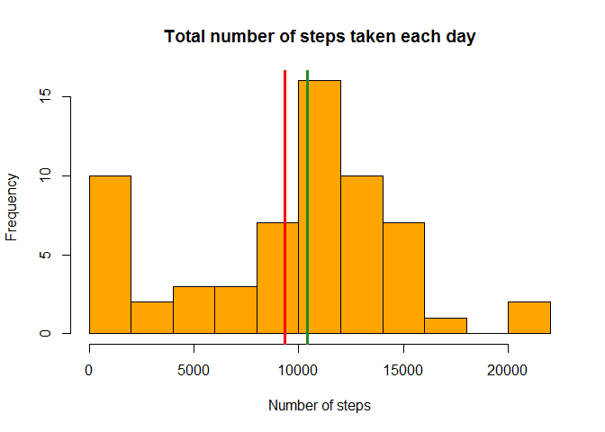

```r
hist(steps_per_date$steps, main = "Total number of steps taken each day",
     xlab = "Number of steps", col = "orange", breaks = 10)
abline(v = mean(steps_per_date$steps), col = "red", lwd = 3)
abline(v = median(steps_per_date$steps), col = "forestgreen", lwd = 3)
```

The mean and the median of the total number of steps taken per day are:

```r
mean(steps_per_date$steps)
```

```
## [1] 9354.23
```

```r
median(steps_per_date$steps)
```

```
## [1] 10395
```

## What is the average daily activity pattern?

At first, I calculate the average number of steps taken, averaged across all days.

```r
avg_steps_per_interval <- dataset %>%
  group_by(interval) %>% summarise(avg_steps = mean(steps, na.rm = TRUE))
```

Then I make a time series plot of the 5-minute interval (x-axis) and the average number of steps taken, averaged across all days (y-axis).  
Here, I added a horizontal line at the maximum number of steps.

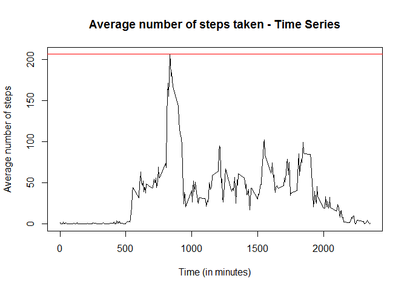

```r
plot(avg_steps_per_interval, type = "l",
     main = "Average number of steps taken - Time Series",
     xlab = "Time (in minutes)", ylab = "Average number of steps")
abline(h = max(avg_steps_per_interval$avg_steps), col = "red", lwd = 1)
```

The interval which contains the maximum number of steps, on average across all the days in the dataset, is calculated as follows.

```r
with(avg_steps_per_interval, interval[avg_steps == max(avg_steps)])
```

```
## [1] 835
```